# Aprendizado não supervisionado em R

# Introdução

- Notas do curso do curso Unsupervisioned Learning in R no DataCamp
- Ministrado por Hank Roark, cientista de dados sênior da Boeing

# Curso os tópicos

- Aprendizado não supervisionado em R
- Agrupamento hierárquico
- Redução de dimensionalidade com PCA
- Juntando tudo com um estudo de caso

# Recursos adicionais

- Fazendo biplots mais agradáveis com ggplot2
- Os 10 principais algoritmos de mineração de dados em inglês simples
- bom artigo que fala sobre k-means e outros algoritmos em inglês simples

# Aprendizado não supervisionado em R

- 3 tipos principais de aprendizado de máquina:
- Objetivo é encontrar estrutura em dados não rotulados dados não rotulados são dados sem destinos.
- Aprendizagem supervisionada: Regressão ou classificação Objetivo é prever a quantidade ou o rótulo.

# Aprendizado por reforço

- Um computador aprende por feedback de operar em um ambiente real ou sintético.

# Dois grandes objetivos:

- Encontrar subgrupos homogêneos dentro de uma população isso é chamado de aglomerados
- Exemplo: segmentação de um mercado de consumidores com base em características demográficas e histórico de compras.
- Exemplo: encontre filmes semelhantes com base nos recursos de cada filme e nas resenhas dos filmes encontrar padrões nas características dos dados.
- Redução de dimensionalidade: Um método para diminuir o número de recursos para descrever uma conservação enquanto mantém o conteúdo máximo de informação sob as restrições de menor dimensionalidade.
- Encontrar padrões nas fetures dos dados.
- Visualização de dados de alta dimensão é difícil produzir boas visualizações além de 3 ou 4 dimensões e também consumir etapa de pré-processamento para aprendizado supervisionado.

# Introdução ao cluster k-means

- Algoritmo usado para encontrar subgrupos homogêneos em uma população.
- K-means vem na base R.
- Número de centros ou grupos.
- Número de corridas. começa atribuindo pontos aleatoriamente aos grupos e você pode encontrar mínimos locais, portanto, executá-lo várias vezes ajuda a encontrar o mínimo global.
- Você pode executar kmeans muitas vezes para estimar o número de subgrupos quando não for conhecido a priori.
- Agrupamento k-means

# Bibliotecas e dados

```r
source('create_datasets.R')
```

# Agrupamento k-means

```r
x <- rbind(matrix(rnorm(5000, sd = 0.3), ncol = 2),
           matrix(rnorm(5000, mean = 1, sd = 0.3), ncol = 2))
head(x)
```

```
           [,1]        [,2]
[1,] -0.7016507 -0.52578813
[2,] -0.2904552 -0.11854048
[3,] -0.3423322  0.42386234
[4,] -0.2667919 -0.28811103
[5,]  0.2378300 -0.44387108
[6,] -0.4639877  0.09530641
```

```r
# Visualizando os dados
str(x)
```

```
 num [1:5000, 1:2] -0.702 -0.29 -0.342 -0.267 0.238 ...
```

# Modelo agrupamento k-means

Modelo k-means: km.out

```r
km.out <- kmeans(x, centers = 3, nstart = 20)
```

# Inspecione o resultado

```r
summary(km.out)
```

```
             Length Class  Mode
cluster      5000   -none- numeric
centers         6   -none- numeric
totss           1   -none- numeric
withinss        3   -none- numeric
tot.withinss    1   -none- numeric
betweenss       1   -none- numeric
size            3   -none- numeric
iter            1   -none- numeric
ifault          1   -none- numeric
```

# Cluster do modelo

```r
km.out$cluster
```

[output not shown]

# Objeto km.out

```r
km.out
```

```
K-means clustering with 3 clusters of sizes 1225, 2469, 1306

Cluster means:
        [,1]        [,2]
1 -0.2578441 -0.03426415
2  1.0024459  0.99792012
3  0.2372794  0.03552874

Clustering vector:
   [1] 1 1 1 1 3 1 3 3 3 3 1 3 3 1 1 3 3 3 1 3 3 3 3 3 3 3 3 3 1 3 3 3 3 3 1 1 1 3 3 1 3 3 1 3 1 1 1 3 1 3 3 1 3 1 3 1 1 3 3 3 1 3 1 3 3 3 3 3 3 3 3 1 1 1 3 1 3 3 1 3 3 3 1 3 1 1 1 1 3 3 3 3 1 1 3 1 3 1 3
 [100] 1 3 1 1 1 3 3 1 1 3 3 1 1 3 1 1 1 3 1 1 1 3 3 3 3 1 1 3 3 1 1 1 3 1 1 3 1 3 1 3 1 3 3 3 2 1 3 3 1 1 1 3 1 3 1 3 1 3 1 3 1 3 3 1 3 1 1 3 1 1 1 1 3 1 1 1 1 1 3 3 3 3 1 3 3 3 3 3 3 1 1 1 1 3 1 3 3 3 1
 [199] 1 1 1 3 1 3 1 1 1 1 3 1 3 1 3 3 1 3 1 3 1 3 3 3 1 3 1 3 1 3 3 3 3 1 3 1 3 3 3 3 1 3 3 1 3 1 3 1 3 3 3 1 1 3 1 1 3 3 1 1 1 3 3 3 1 1 3 3 1 1 3 1 1 1 1 3 1 3 3 3 3 3 1 1 1 1 1 3 3 1 3 1 1 1 1 1 1 3 3
 [298] 3 3 3 3 3 1 1 1 1 3 1 3 3 3 1 1 3 3 1 1 1 1 3 3 3 1 1 3 3 1 1 3 1 1 1 1 3 1 1 3 1 1 1 3 1 1 1 3 1 3 3 3 1 1 1 3 3 1 1 1 3 1 1 1 3 1 3 1 1 3 3 3 1 3 3 3 1 3 3 3 3 1 3 3 1 1 1 1 3 3 1 1 3 3 1 1 1 1 1
 [397] 1 3 1 3 3 3 1 1 3 1 1 3 3 1 1 1 1 3 1 3 3 3 1 3 1 1 3 1 1 3 1 3 1 1 1 3 1 3 1 3 1 3 3 1 3 1 1 1 1 1 1 3 1 3 1 3 3 3 1 3 3 1 1 1 1 3 3 3 3 1 3 3 1 1 1 1 3 3 3 3 3 3 1 3 3 3 1 3 1 3 3 1 1 3 2 1 3 3 3
 [496] 3 1 3 1 3 3 3 3 3 1 3 1 1 1 3 1 3 1 1 3 3 1 3 1 1 1 3 3 1 1 1 3 1 3 1 1 3 3 2 3 3 3 3 1 1 1 3 3 3 3 3 3 1 1 3 1 1 1 1 3 1 1 3 3 3 3 3 3 3 1 1 1 3 3 1 1 1 3 3 3 3 3 3 3 3 1 1 3 3 1 1 3 1 3 3 3 3 3 1
 [595] 3 3 1 1 1 1 3 1 3 3 1 3 3 3 1 1 1 1 3 1 3 3 1 3 3 1 3 1 1 1 1 3 3 1 1 3 1 3 1 3 1 1 3 3 3 1 3 3 3 1 3 3 3 1 3 3 3 3 3 1 1 1 1 3 1 3 3 1 1 1 1 3 1 3 1 1 1 3 3 1 1 1 3 3 3 3 3 3 1 3 1 3 3 1 3 3 1 1 3
 [694] 1 3 1 3 1 1 1 2 3 1 1 3 1 3 3 3 1 1 1 3 3 3 1 3 1 1 1 1 3 3 1 1 3 1 1 1 1 3 1 1 2 3 3 3 3 1 1 1 1 1 1 3 3 1 3 1 1 3 1 1 1 3 1 1 1 3 3 1 1 3 3 3 3 1 3 3 1 3 3 1 1 3 1 3 3 1 3 3 1 3 1 3 1 1 1 1 3 1 3
 [793] 3 3 3 3 3 3 1 1 1 3 3 1 3 3 3 1 3 1 3 3 1 1 1 3 3 1 3 1 3 3 1 1 3 3 3 1 3 1 1 1 3 3 1 3 3 3 3 1 3 3 3 1 1 3 1 1 1 1 3 1 1 3 1 3 1 3 1 3 3 1 1 3 1 3 3 3 3 1 1 3 3 1 3 3 1 3 3 3 1 3 3 1 3 1 3 1 1 3 3
 [892] 3 3 1 1 3 1 3 1 1 3 3 1 3 1 1 1 1 1 1 1 1 3 3 3 3 3 1 3 1 1 3 1 1 1 1 3 1 3 1 3 1 1 1 3 3 3 1 1 1 3 1 3 3 3 3 3 3 3 3 1 3 1 1 3 3 1 3 2 3 1 1 3 1 1 1 3 1 3 3 1 3 1 3 3 1 3 1 1 1 3 1 3 1 1 3 1 3 3 1
 [991] 1 3 3 3 3 3 3 3 1 3
 [ reached getOption("max.print") -- omitted 4000 entries ]

Within cluster sum of squares by cluster:
[1] 153.7002 419.9855 156.5283
 (between_SS / total_SS =  78.5 %)

Available components:

[1] "cluster"      "centers"      "totss"        "withinss"     "tot.withinss" "betweenss"    "size"         "iter"         "ifault"
```

# Gráfico Scatter plot

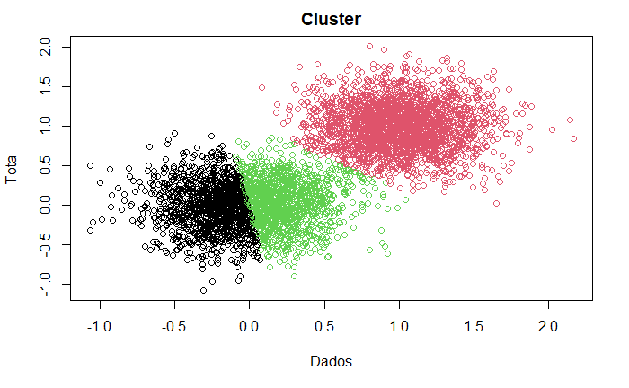

# Configurar grade de plotagem 2 x 3

```r
par(mfrow = c(2, 3))
```

# Definir seed

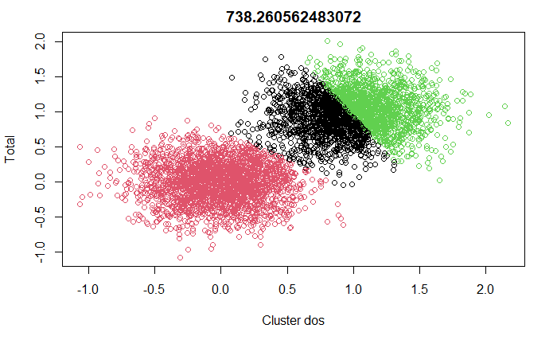

# Manipulando algoritmos aleatórios

- Configurar grade de plotagem 2 x 3

# Como kmeans() funciona e questões práticas

- Processo de k-médias:
  - Atribuir aleatoriamente todos os pontos a um cluster
  - Calcular o centro de cada cluster
  - Converter pontos para cluster do centro mais próximo
  - Se nenhum ponto mudou, feito, caso contrário, repita
  - Calcular novos pontos baseados no novo centro
  - Converter pontos para cluster do centro mais próximo e assim por diante
- Seleção do modelo:
  - O melhor resultado é baseado no total dentro da soma dos quadrados do cluster
  - Executar muitas vezes para obter o ótimo global
  - R irá automaticamente executar a corrida com o menor valor total
- Determinando o número de clusters
  - Enredo de seixos
  - Procure o cotovelo
  - Descobrir onde a adição no novo cluster não muda melhor dentro de muito
  - Geralmente não há cotovelo claro em dados do mundo real

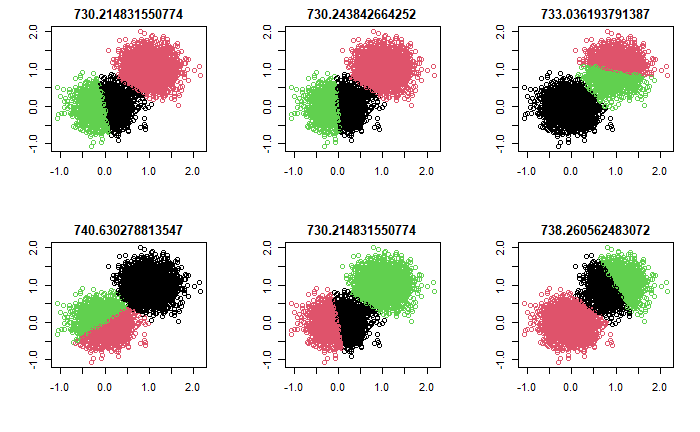

```r
# Set up 2 x 3 plotting grid
par(mfrow = c(2, 3))

# Set seed
set.seed(1)

for(i in 1:6) {
  # Run kmeans() on x with three clusters and one start
  km.out <- kmeans(x, centers = 3, nstart = 1)

  # Plot clusters
  plot(x, col = km.out$cluster,
       main = km.out$tot.withinss,
       xlab = "", ylab = "")
}
```

# Selecionando o número de clusters

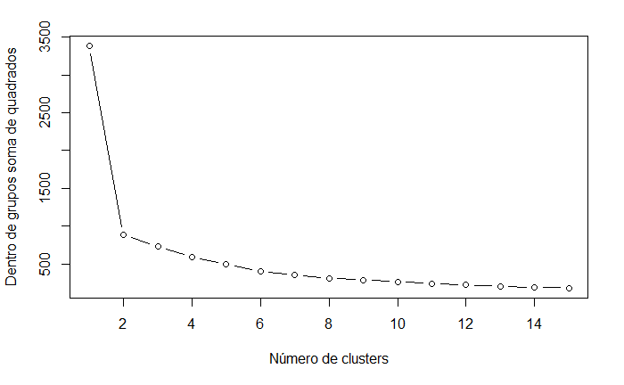

```r
# Inicializa o total dentro do erro de soma dos quadrados: wss
wss <- 0

# Para 1 a 15 centros de cluster
for (i in 1:15) {
  km.out <- kmeans(x, centers = i, nstart = 20)
  # Salva o total dentro da soma dos quadrados na variável wss
  wss[i] <- km.out$tot.withinss
}
# Plotar o total dentro da soma dos quadrados e. número de clusters
plot(1:15, wss, type = "b",
     xlab = "Número de clusters",
     ylab = "Dentro de grupos soma de quadrados")
```

# Introdução ao agrupamento hierárquico

- Normalmente usado quando o número de clusters não é conhecido antes do tempo
- Duas abordagens. de baixo para cima e de cima para baixo. vamos nos concentrar em baixo para cima

# Processar

- Atribuir cada ponto ao seu próprio cluster
- Juntando os dois clientes/pontos mais próximos em um novo cluster
- Continue até que haja um cluster
- A maneira como você calcula a distância entre os clusters é um parâmetro e será abordado mais tarde
- Temos que primeiro calcular a distância euclidiana entre todos os pontos (faz uma grande matriz) usando a função dist()
- Isso é passado para a função hclust()

# Agrupamento hierárquico com resultados

```r
head(x)
```

```
           [,1]        [,2]
[1,] -0.7016507 -0.52578813
[2,] -0.2904552 -0.11854048
[3,] -0.3423322  0.42386234
[4,] -0.2667919 -0.28811103
[5,]  0.2378300 -0.44387108
[6,] -0.4639877  0.09530641
```

# Criar modelo de cluster hierárquico: hclust.out

```r
hclust.out <- hclust(dist(x))

# O resultado do modelo
summary(hclust.out)
```

```
            Length Class  Mode
merge       9998   -none- numeric
height      4999   -none- numeric
order       5000   -none- numeric
labels         0   -none- NULL
method         1   -none- character
call           2   -none- call
dist.method    1   -none- character
```

# Selecionando o número de clusters

- Você pode construir um dendrograma das distâncias entre os pontos
- Então você escolhe o número de clusters ou a altura (também conhecida como distância) que deseja dividir o cluster.
- Pense nisso como desenhar uma linha horizontal através do dendrograma
- A função cutree() em R permite dividir os clusters hierárquicos em clusters definidos por número ou por distância (altura)

# Gráfico

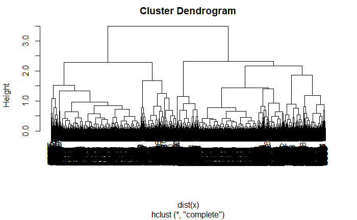

```r
plot(hclust.out)
abline(h = 7, col = "red")
```

# Corte por altura

```r
# Corte por altura
cutree(hclust.out, h = 7)
```

[output not shown]

# Número de clusters

```r
# Número de clusters

cutree(hclust.out, k = 3)
```

[output not shown]

# Clusters e questões práticas

- 4 métodos para medir a distância entre clusters
  - Completo: semelhança de pares entre todas as observações no cluster 1 e 2, usa a maior das semelhanças
  - Single: o mesmo que acima, mas usa a menor das semelhanças
  - Média: o mesmo que acima, mas usa média de semelhanças
  - Centróide: encontra o centróide do cluster 1 e 2, usa semelhança entre dois centróides
- Regra de ouro
  - Completas e médias produzem árvores mais equilibradas e são mais comumente usadas
  - Single funde as observações uma de cada vez e produz mais árvores não balanceadas
  - Centroid pode criar inversão onde os clusters são colocados abaixo de valores únicos. não é usado com frequência
- Assuntos práticos
  - Os dados precisam ser dimensionados para que os recursos tenham a mesma média e desvio padrão
  - Características normalizadas têm uma média de zero e um sd de um

# Métodos de ligação

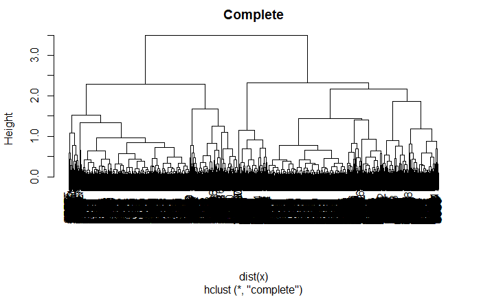

```r
# Cluster using complete linkage: hclust.complete
hclust.complete <- hclust(dist(x), method = "complete")

# Cluster using average linkage: hclust.average
hclust.average <- hclust(dist(x), method = "average")

# Cluster using single linkage: hclust.single
hclust.single <- hclust(dist(x), method = "single")

# Plot dendrogram of hclust.complete
plot(hclust.complete, main = "Complete")
```

# Plotar dendrograma de hclust.average

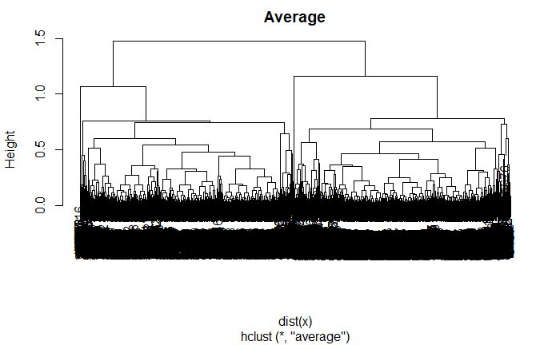

```r
plot(hclust.average, main = "Average")
```

# Introdução ao PCA

Redução de dimensionalidade com PCA

- Dois objetivos principais de redução de dimensionalidade
  - Encontrar estrutura em recursos
  - Ajuda na visualização
- PCA tem 3 objetivos
  - Encontre uma combinação linear de variáveis para criar componentes principais
  - Manter tanta variação nos dados quanto possível
  - Componentes principais não são correlacionados (ou seja, ortogonais entre si)
- Intuição
  - Com um gráfico de dispersão de correlação x y, a melhor dimensão 1 para explicar a variância nos dados é a linha de regressão linear
  - Este é o primeiro componente principal
  - Então a distância dos pontos da linha é a pontuação do componente (eu realmente não entendo essa parte, mas entendo como a linha é uma maneira simples de explicar os dados bidimensionais e explica a maior parte da variação nos dados.)
- Exemplo: componentes principais com conjunto de dados de íris
  - Centro e escala - para cada ponto, subtraia a média e divida pelo dp
  - O resumo do modelo mostra a proporção de variância explicada por cada componente principal
  - Eu acho que a rotação é a distância do ponto de cada componente principal ou algo assim.

# Dados PCA com iris

```r
summary(iris)
```

```
  Sepal.Length    Sepal.Width     Petal.Length    Petal.Width          Species
 Min.   :4.300   Min.   :2.000   Min.   :1.000   Min.   :0.100   setosa    :50
 1st Qu.:5.100   1st Qu.:2.800   1st Qu.:1.600   1st Qu.:0.300   versicolor:50
 Median :5.800   Median :3.000   Median :4.350   Median :1.300   virginica :50
 Mean   :5.843   Mean   :3.057   Mean   :3.758   Mean   :1.199
 3rd Qu.:6.400   3rd Qu.:3.300   3rd Qu.:5.100   3rd Qu.:1.800
 Max.   :7.900   Max.   :4.400   Max.   :6.900   Max.   :2.500
```

# Dados PCA

```r
pr.iris
```

```
Standard deviations (1, .., p=4):
[1] 2.0562689 0.4926162 0.2796596 0.1543862

Rotation (n x k) = (4 x 4):
                     PC1         PC2         PC3        PC4
Sepal.Length  0.36138659 -0.65658877  0.58202985  0.3154872
Sepal.Width  -0.08452251 -0.73016143 -0.59791083 -0.3197231
Petal.Length  0.85667061  0.17337266 -0.07623608 -0.4798390
Petal.Width   0.35828920  0.07548102 -0.54583143  0.7536574
```

# Resultado do PCA

```r
pr.iris
```

```
Standard deviations (1, .., p=4):
[1] 2.0562689 0.4926162 0.2796596 0.1543862

Rotation (n x k) = (4 x 4):
                     PC1         PC2         PC3        PC4
Sepal.Length  0.36138659 -0.65658877  0.58202985  0.3154872
Sepal.Width  -0.08452251 -0.73016143 -0.59791083 -0.3197231
Petal.Length  0.85667061  0.17337266 -0.07623608 -0.4798390
Petal.Width   0.35828920  0.07548102 -0.54583143  0.7536574
```

# Resultados do PCA

- Os modelos PCA produzem componentes adicionais de diagnóstico e saída:
  - Center - o meio da coluna usado para centralizar os dados
  - Scale - a coluna sd usada para dimensionar os dados
  - Rotacao - a direcao dos vetores prin comp em termos das feições/variáveis originais. Essas informações de alguma forma permitem que você defina novos dados em termos dos componentes principais originais.
  - x o valor de cada observação no conjunto de dados original projetado para os componentes principais.

# Visualizando e interpretando os resultados do PCA

- Biplot
  - Mostra todas as observações originais como pontos plotados pelos 2 primeiros componentes principais ele também mostra os recursos originais como vetores mapeados nos 2 primeiros componentes principais.
  - Com os dados da íris observe como a largura e o comprimento do pedal estão apontando na mesma direção
  - Isso significa que as variáveis estão correlacionadas. um explica a cerca de toda a variância do outro.
  - Encontrei uma função biplot melhor PCbiplot() no estouro de pilha, feita com ggplot2 e modifiquei isso para funcionar um pouco melhor. Eu uso isso na maioria dos casos porque é muito mais claro.
- Scree plot
  - Mostra a proporção de variância explicada por cada componente principal ou a variância cumulativa explicada por componentes sucessivos
  - Toda a variação é explicada quando o número de componentes corresponde ao número de recursos/variáveis originais
  - Alguns passos são necessários para obter a variação do sd para cada componente do gráfico

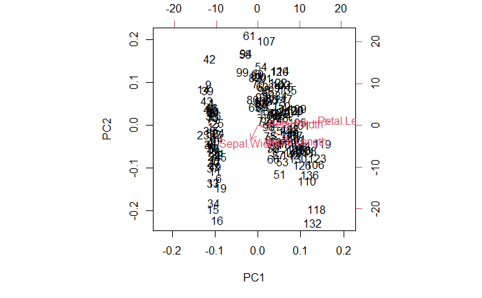

```r
# Criando um biplot
# Isso não parece tão bonito quanto o que ele tinha no vídeo

biplot(pr.iris)
```

# Gráfico

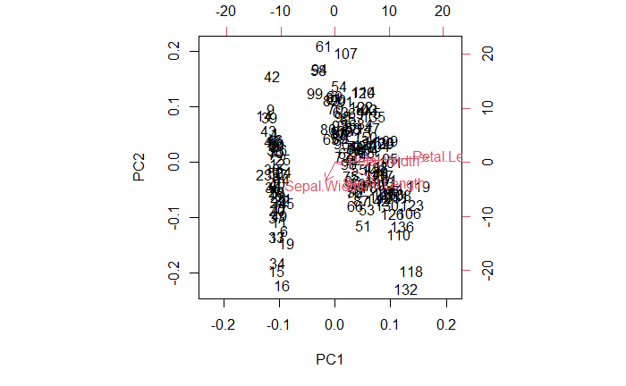

```r
biplot(pr.iris)
```

# Obtendo proporção de variância para um scree plot

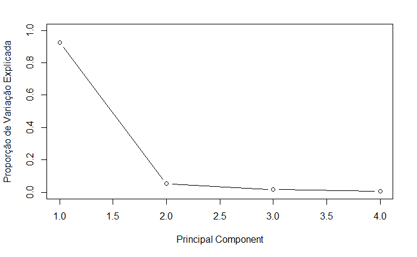

# Problemas práticos com PCA

3 coisas precisam ser consideradas para um PCA bem-sucedido:

- Dimensionando os dados Dados ausentes
  - Ou abandoná-lo ou imputá-lo
  - Características que são categorias
- Solte-o ou codifique-o como números
  - Isso não é abordado nesta aula (é necessário muito mais pré-processamento em aplicações do mundo real do que estamos fazendo aqui, acredito)
  - Importância do escalonamento:
- O conjunto de dados mtcars tem meios e sd muito diferentes
  - Veja os resultados dos biplots com e sem escala
  - Sem dimensionar o disp e o hp sobrecarregam os outros recursos simplesmente porque eles têm uma variação muito maior em suas unidades de medida

```r
data(mtcars)
head(mtcars)
```

|  | mpg | cyl | disp | hp | drat | wt | qsec | vs | am | gear | carb |
| --- | --- | --- | --- | --- | --- | --- | --- | --- | --- | --- | --- |
| Mazda RX4 | 21.0 | 6 | 160 | 110 | 3.90 | 2.620 | 16.46 | 0 | 1 | 4 | 4 |
| Mazda RX4 Wag | 21.0 | 6 | 160 | 110 | 3.90 | 2.875 | 17.02 | 0 | 1 | 4 | 4 |
| Datsun 710 | 22.8 | 4 | 108 | 93 | 3.85 | 2.320 | 18.61 | 1 | 1 | 4 | 1 |
| Hornet 4 Drive | 21.4 | 6 | 258 | 110 | 3.08 | 3.215 | 19.44 | 1 | 0 | 3 | 1 |
| Hornet Sportabout | 18.7 | 8 | 360 | 175 | 3.15 | 3.440 | 17.02 | 0 | 0 | 3 | 2 |
| Valiant | 18.1 | 6 | 225 | 105 | 2.76 | 3.460 | 20.22 | 1 | 0 | 3 | 1 |

# Resultado

```r
# Resultado
round(colMeans(mtcars), 2)
```

```
   mpg    cyl   disp     hp   drat     wt   qsec     vs     am   gear   carb
 20.09   6.19 230.72 146.69   3.60   3.22  17.85   0.44   0.41   3.69   2.81
```

# Resultado 2

```r
# Resultado 2
round(apply(mtcars, 2, sd), 2)
```

```
   mpg    cyl   disp     hp   drat     wt   qsec     vs     am   gear   carb
  6.03   1.79 123.94  68.56   0.53   0.98   1.79   0.50   0.50   0.74   1.62
```

# Gráfico

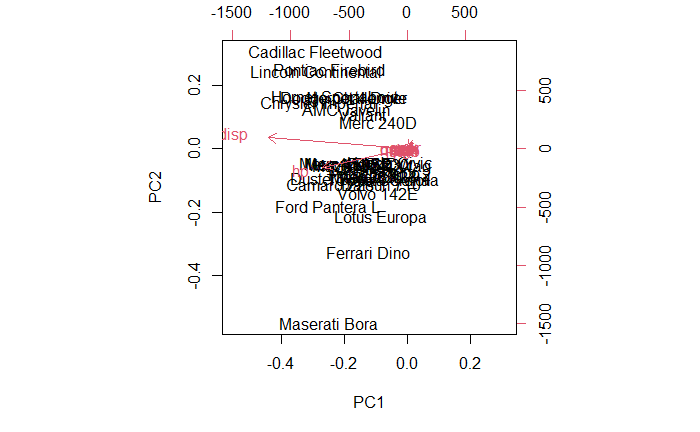

```r
pr.mtcars_no_scale <- prcomp(x = mtcars, scale = F, center = F)
pr.mtcars_scale <- prcomp(x = mtcars, scale = T, center = T)

biplot(pr.mtcars_no_scale)
```

# Gráfico do escalonamento

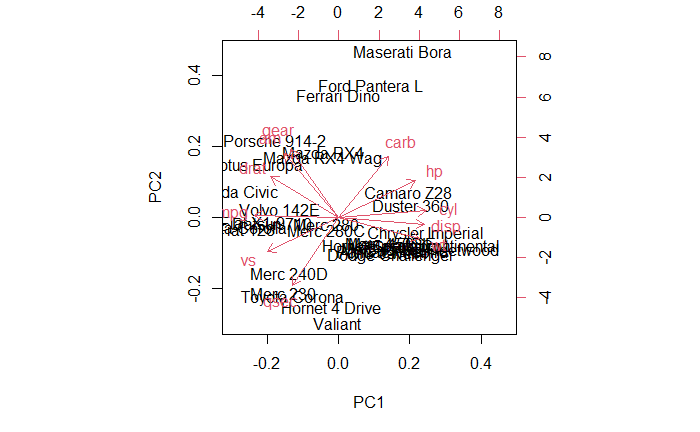

```r
biplot(pr.mtcars_scale)
```

# Projeto na prática - Modelo ML Câncer

# Introdução ao estudo de caso

- Dados do artigo de Bennet e Mangasarian.
  - “Discriminação de programação linear robusta de dois conjuntos linearmente inseparáveis”
  - Massa de mama humana que era ou não maligna
- 10 características medidas de cada núcleo de célula (embora eu veja 30)
  - Cada característica é uma estatística resumida das células naquela massa
  - Inclui diagnóstico (alvo) - pode ser usado para aprendizado supervisionado, mas não será usado durante a análise não supervisionada
  - Etapas gerais

# Baixar e preparar dados

- EDA
- Realizar PCA e interpretar os resultados
- Tupes twy completos de agrupamento
- Entenda e compare os dois tipos
- Combinar PCA e clustering – Preparando os dados

# Dados

# Preparando os dados

```r
# Baixe os dados: wisc.df
wisc.df <- read.csv(url)
str(wisc.df)
```

```
'data.frame':   569 obs. of  33 variables:
 $ id                     : int  842302 842517 84300903 84348301 84358402 843786 844359 84458202 844981 84501001 ...
 $ diagnosis              : chr  "M" "M" "M" "M" ...
 $ radius_mean            : num  18 20.6 19.7 11.4 20.3 ...
 $ texture_mean           : num  10.4 17.8 21.2 20.4 14.3 ...
 $ perimeter_mean         : num  122.8 132.9 130 77.6 135.1 ...
 $ area_mean              : num  1001 1326 1203 386 1297 ...
 $ smoothness_mean        : num  0.1184 0.0847 0.1096 0.1425 0.1003 ...
 $ compactness_mean       : num  0.2776 0.0786 0.1599 0.2839 0.1328 ...
 $ concavity_mean         : num  0.3001 0.0869 0.1974 0.2414 0.198 ...
 $ concave.points_mean    : num  0.1471 0.0702 0.1279 0.1052 0.1043 ...
 $ symmetry_mean          : num  0.242 0.181 0.207 0.26 0.181 ...
 $ fractal_dimension_mean : num  0.0787 0.0567 0.06 0.0974 0.0588 ...
 $ radius_se              : num  1.095 0.543 0.746 0.496 0.757 ...
 $ texture_se             : num  0.905 0.734 0.787 1.156 0.781 ...
```

[output cut: 19 more lines]

# Converte as características dos dados: wisc.data

```r
# Dados
wisc.data <- as.matrix(wisc.df[, 3:32])
str(wisc.data)
```

```
 num [1:569, 1:30] 18 20.6 19.7 11.4 20.3 ...
 - attr(*, "dimnames")=List of 2
  ..$ : NULL
  ..$ : chr [1:30] "radius_mean" "texture_mean" "perimeter_mean" "area_mean" ...
```

# Visualizando os dados

```r
# Visualizando os cinco primeiros dados
head(wisc.data)
```

```
     radius_mean texture_mean perimeter_mean area_mean smoothness_mean compactness_mean concavity_mean concave.points_mean symmetry_mean fractal_dimension_mean radius_se texture_se perimeter_se area_se
[1,]       17.99        10.38         122.80    1001.0         0.11840          0.27760         0.3001             0.14710        0.2419                0.07871    1.0950     0.9053        8.589  153.40
[2,]       20.57        17.77         132.90    1326.0         0.08474          0.07864         0.0869             0.07017        0.1812                0.05667    0.5435     0.7339        3.398   74.08
[3,]       19.69        21.25         130.00    1203.0         0.10960          0.15990         0.1974             0.12790        0.2069                0.05999    0.7456     0.7869        4.585   94.03
[4,]       11.42        20.38          77.58     386.1         0.14250          0.28390         0.2414             0.10520        0.2597                0.09744    0.4956     1.1560        3.445   27.23
[5,]       20.29        14.34         135.10    1297.0         0.10030          0.13280         0.1980             0.10430        0.1809                0.05883    0.7572     0.7813        5.438   94.44
[6,]       12.45        15.70          82.57     477.1         0.12780          0.17000         0.1578             0.08089        0.2087                0.07613    0.3345     0.8902        2.217   27.19
     smoothness_se compactness_se concavity_se concave.points_se symmetry_se fractal_dimension_se radius_worst texture_worst perimeter_worst area_worst smoothness_worst compactness_worst concavity_worst
[1,]      0.006399        0.04904      0.05373           0.01587     0.03003             0.006193        25.38         17.33          184.60     2019.0           0.1622            0.6656          0.7119
[2,]      0.005225        0.01308      0.01860           0.01340     0.01389             0.003532        24.99         23.41          158.80     1956.0           0.1238            0.1866          0.2416
[3,]      0.006150        0.04006      0.03832           0.02058     0.02250             0.004571        23.57         25.53          152.50     1709.0           0.1444            0.4245          0.4504
[4,]      0.009110        0.07458      0.05661           0.01867     0.05963             0.009208        14.91         26.50           98.87      567.7           0.2098            0.8663          0.6869
[5,]      0.011490        0.02461      0.05688           0.01885     0.01756             0.005115        22.54         16.67          152.20     1575.0           0.1374            0.2050          0.4000
[6,]      0.007510        0.03345      0.03672           0.01137     0.02165             0.005082        15.47         23.75          103.40      741.6           0.1791            0.5249          0.5355
     concave.points_worst symmetry_worst fractal_dimension_worst
[1,]               0.2654         0.4601                 0.11890
[2,]               0.1860         0.2750                 0.08902
[3,]               0.2430         0.3613                 0.08758
[4,]               0.2575         0.6638                 0.17300
[5,]               0.1625         0.2364                 0.07678
[6,]               0.1741         0.3985                 0.12440
```

# Visualizando linhas e colunas

```r
# Visualizando linhas e colunas
dim(wisc.data)
```

```
[1] 569  30
```

# Defina os nomes das linhas de wisc.data

```r
row.names(wisc.data) <- wisc.df$id
head(wisc.data)
```

```
         radius_mean texture_mean perimeter_mean area_mean smoothness_mean compactness_mean concavity_mean concave.points_mean symmetry_mean fractal_dimension_mean radius_se texture_se perimeter_se
842302         17.99        10.38         122.80    1001.0         0.11840          0.27760         0.3001             0.14710        0.2419                0.07871    1.0950     0.9053        8.589
842517         20.57        17.77         132.90    1326.0         0.08474          0.07864         0.0869             0.07017        0.1812                0.05667    0.5435     0.7339        3.398
84300903       19.69        21.25         130.00    1203.0         0.10960          0.15990         0.1974             0.12790        0.2069                0.05999    0.7456     0.7869        4.585
84348301       11.42        20.38          77.58     386.1         0.14250          0.28390         0.2414             0.10520        0.2597                0.09744    0.4956     1.1560        3.445
84358402       20.29        14.34         135.10    1297.0         0.10030          0.13280         0.1980             0.10430        0.1809                0.05883    0.7572     0.7813        5.438
843786         12.45        15.70          82.57     477.1         0.12780          0.17000         0.1578             0.08089        0.2087                0.07613    0.3345     0.8902        2.217
         area_se smoothness_se compactness_se concavity_se concave.points_se symmetry_se fractal_dimension_se radius_worst texture_worst perimeter_worst area_worst smoothness_worst compactness_worst
842302    153.40      0.006399        0.04904      0.05373           0.01587     0.03003             0.006193        25.38         17.33          184.60     2019.0           0.1622            0.6656
842517     74.08      0.005225        0.01308      0.01860           0.01340     0.01389             0.003532        24.99         23.41          158.80     1956.0           0.1238            0.1866
84300903   94.03      0.006150        0.04006      0.03832           0.02058     0.02250             0.004571        23.57         25.53          152.50     1709.0           0.1444            0.4245
84348301   27.23      0.009110        0.07458      0.05661           0.01867     0.05963             0.009208        14.91         26.50           98.87      567.7           0.2098            0.8663
84358402   94.44      0.011490        0.02461      0.05688           0.01885     0.01756             0.005115        22.54         16.67          152.20     1575.0           0.1374            0.2050
843786     27.19      0.007510        0.03345      0.03672           0.01137     0.02165             0.005082        15.47         23.75          103.40      741.6           0.1791            0.5249
         concavity_worst concave.points_worst symmetry_worst fractal_dimension_worst
842302            0.7119               0.2654         0.4601                 0.11890
842517            0.2416               0.1860         0.2750                 0.08902
84300903          0.4504               0.2430         0.3613                 0.08758
84348301          0.6869               0.2575         0.6638                 0.17300
84358402          0.4000               0.1625         0.2364                 0.07678
843786            0.5355               0.1741         0.3985                 0.12440
```

# Criando a coluna diagnóstico

```r
diagnosis
```

```
  [1] 1 1 1 1 1 1 1 1 1 1 1 1 1 1 1 1 1 1 1 0 0 0 1 1 1 1 1 1 1 1 1 1 1 1 1 1 1 0 1 1 1 1 1 1 1 1 0 1 0 0 0 0 0 1 1 0 1 1 0 0 0 0 1 0 1 1 0 0 0 0 1 0 1 1 0 1 0 1 1 0 0 0 1 1 0 1 1 1 0 0 0 1 0 0 1 1 0 0 0
[100] 1 1 0 0 0 0 1 0 0 1 0 0 0 0 0 0 0 0 1 1 1 0 1 1 0 0 0 1 1 0 1 0 1 1 0 1 1 0 0 1 0 0 1 0 0 0 0 1 0 0 0 0 0 0 0 0 0 1 0 0 0 0 1 1 0 1 0 0 1 1 0 0 1 1 0 0 0 0 1 0 0 1 1 1 0 1 0 1 0 0 0 1 0 0 1 1 0 1 1
[199] 1 1 0 1 1 1 0 1 0 1 0 0 1 0 1 1 1 1 0 0 1 1 0 0 0 1 0 0 0 0 0 1 1 0 0 1 0 0 1 1 0 1 0 0 0 0 1 0 0 0 0 0 1 0 1 1 1 1 1 1 1 1 1 1 1 1 1 1 0 0 0 0 0 0 1 0 1 0 0 1 0 0 1 0 1 1 0 0 0 0 0 0 0 0 0 0 0 0 0
[298] 1 0 0 1 0 1 0 0 0 0 0 0 0 0 0 0 0 0 0 0 1 0 0 0 1 0 1 0 0 0 0 1 1 1 0 0 0 0 1 0 1 0 1 0 0 0 1 0 0 0 0 0 0 0 1 1 1 0 0 0 0 0 0 0 0 0 0 0 1 1 0 1 1 1 0 1 1 0 0 0 0 0 1 0 0 0 0 0 1 0 0 0 1 0 0 1 1 0 0
[397] 0 0 0 0 1 0 0 0 0 0 0 0 1 0 0 0 0 0 1 0 0 1 0 0 0 0 0 0 0 0 0 0 0 0 1 0 1 1 0 1 0 0 0 0 0 1 0 0 1 0 1 0 0 1 0 1 0 0 0 0 0 0 0 0 1 1 0 0 0 0 0 0 1 0 0 0 0 0 0 0 0 0 0 1 0 0 0 0 0 0 0 1 0 1 0 0 1 0 0
[496] 0 0 0 1 1 0 1 0 1 0 0 0 0 0 1 0 0 1 0 1 0 1 1 0 0 0 1 0 0 0 0 0 0 0 0 0 0 0 1 0 1 1 0 0 0 0 0 0 0 0 0 0 0 0 0 0 0 0 0 0 0 0 0 0 0 0 0 1 1 1 1 1 1 0
```

# Análise exploratória de dados

- Quantas observações estão neste conjunto de dados? 569
- Quantas variáveis/recursos nos dados são sufixados com _mean? 10
- Quantas das observações têm um diagnóstico maligno? 212

```r
str(wisc.data)
```

```
 num [1:569, 1:30] 18 20.6 19.7 11.4 20.3 ...
 - attr(*, "dimnames")=List of 2
  ..$ : chr [1:569] "842302" "842517" "84300903" "84348301" ...
  ..$ : chr [1:30] "radius_mean" "texture_mean" "perimeter_mean" "area_mean" ...
```

```r
colnames(wisc.data)
```

```
 [1] "radius_mean"             "texture_mean"            "perimeter_mean"          "area_mean"               "smoothness_mean"         "compactness_mean"        "concavity_mean"
 [8] "concave.points_mean"     "symmetry_mean"           "fractal_dimension_mean"  "radius_se"               "texture_se"              "perimeter_se"            "area_se"
[15] "smoothness_se"           "compactness_se"          "concavity_se"            "concave.points_se"       "symmetry_se"             "fractal_dimension_se"    "radius_worst"
[22] "texture_worst"           "perimeter_worst"         "area_worst"              "smoothness_worst"        "compactness_worst"       "concavity_worst"         "concave.points_worst"
[29] "symmetry_worst"          "fractal_dimension_worst"
```

```r
table(diagnosis)
```

```
diagnosis
  0   1
357 212
```

# Executando PCA

```r
# Verifique as médias das colunas e os desvios padrão
round(colMeans(wisc.data), 2)
```

```
            radius_mean            texture_mean          perimeter_mean               area_mean         smoothness_mean        compactness_mean          concavity_mean     concave.points_mean
                  14.13                   19.29                   91.97                  654.89                    0.10                    0.10                    0.09                    0.05
          symmetry_mean  fractal_dimension_mean               radius_se              texture_se            perimeter_se                 area_se           smoothness_se          compactness_se
                   0.18                    0.06                    0.41                    1.22                    2.87                   40.34                    0.01                    0.03
           concavity_se       concave.points_se             symmetry_se    fractal_dimension_se            radius_worst           texture_worst         perimeter_worst              area_worst
                   0.03                    0.01                    0.02                    0.00                   16.27                   25.68                  107.26                  880.58
       smoothness_worst       compactness_worst         concavity_worst    concave.points_worst          symmetry_worst fractal_dimension_worst
                   0.13                    0.25                    0.27                    0.11                    0.29                    0.08
```

```r
round(apply(wisc.data, 2, sd), 2)
```

```
            radius_mean            texture_mean          perimeter_mean               area_mean         smoothness_mean        compactness_mean          concavity_mean     concave.points_mean
                   3.52                    4.30                   24.30                  351.91                    0.01                    0.05                    0.08                    0.04
          symmetry_mean  fractal_dimension_mean               radius_se              texture_se            perimeter_se                 area_se           smoothness_se          compactness_se
                   0.03                    0.01                    0.28                    0.55                    2.02                   45.49                    0.00                    0.02
           concavity_se       concave.points_se             symmetry_se    fractal_dimension_se            radius_worst           texture_worst         perimeter_worst              area_worst
                   0.03                    0.01                    0.01                    0.00                    4.83                    6.15                   33.60                  569.36
       smoothness_worst       compactness_worst         concavity_worst    concave.points_worst          symmetry_worst fractal_dimension_worst
                   0.02                    0.16                    0.21                    0.07                    0.06                    0.02
```

```r
# Executa o PCA, dimensionando se apropriado: wisc.pr
wisc.pr <- prcomp(wisc.data, scale = T, center = T)

# Veja o resumo dos resultados
summary(wisc.pr)
```

```
Importance of components:
                          PC1    PC2     PC3     PC4     PC5     PC6     PC7     PC8    PC9    PC10   PC11    PC12    PC13    PC14    PC15    PC16    PC17    PC18    PC19    PC20   PC21    PC22    PC23
Standard deviation     3.6444 2.3857 1.67867 1.40735 1.28403 1.09880 0.82172 0.69037 0.6457 0.59219 0.5421 0.51104 0.49128 0.39624 0.30681 0.28260 0.24372 0.22939 0.22244 0.17652 0.1731 0.16565 0.15602
Proportion of Variance 0.4427 0.1897 0.09393 0.06602 0.05496 0.04025 0.02251 0.01589 0.0139 0.01169 0.0098 0.00871 0.00805 0.00523 0.00314 0.00266 0.00198 0.00175 0.00165 0.00104 0.0010 0.00091 0.00081
Cumulative Proportion  0.4427 0.6324 0.72636 0.79239 0.84734 0.88759 0.91010 0.92598 0.9399 0.95157 0.9614 0.97007 0.97812 0.98335 0.98649 0.98915 0.99113 0.99288 0.99453 0.99557 0.9966 0.99749 0.99830
                         PC24    PC25    PC26    PC27    PC28    PC29    PC30
Standard deviation     0.1344 0.12442 0.09043 0.08307 0.03987 0.02736 0.01153
Proportion of Variance 0.0006 0.00052 0.00027 0.00023 0.00005 0.00002 0.00000
Cumulative Proportion  0.9989 0.99942 0.99969 0.99992 0.99997 1.00000 1.00000
```

# Interpretando os resultados do PCA

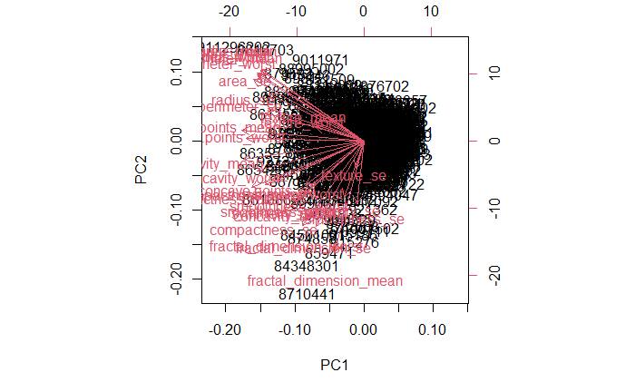

```r
# Cria um biplot de wisc.pr
biplot(wisc.pr)
```

# Gráfico scatter plot

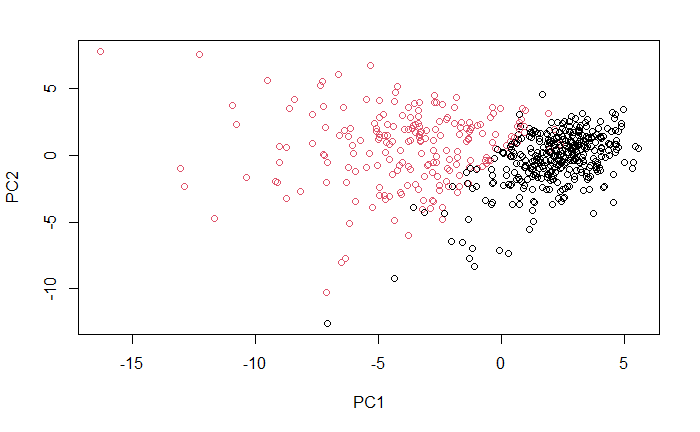

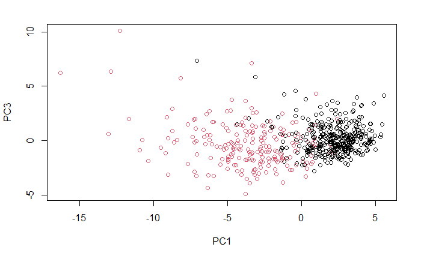

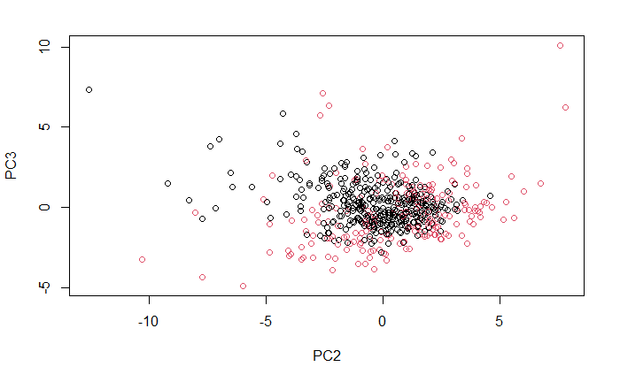

- Podemos ver nos gráficos que pc1 e pc2 se sobrepõem menos que pc1 e pc3.
  - Isso é esperado, pois pc1 e pc2 devem ser ortogonais e explicar diferentes variâncias
- PC2 e PC3 se sobrepõem mais do que qualquer um deles se sobrepõe com pc1

# Variação explicada

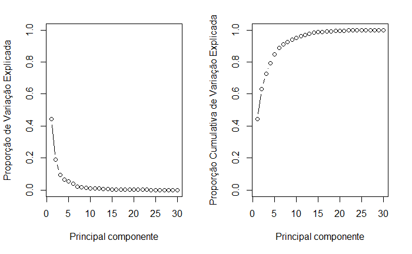

```r
# Configurar grade de plotagem 1 x 2
par(mfrow = c(1, 2))

# Calcula a variabilidade de cada componente
pr.var <- wisc.pr$sdev^2

# Variação explicada por cada componente principal: pve
pve <- pr.var / sum(pr.var)

# Variação do gráfico explicada para cada componente principal
plot(pve, xlab = "Principal componente",
     ylab = "Proporção de Variação Explicada",
     ylim = c(0, 1), type = "b")

# Plotar proporção cumulativa de variância explicada
plot(cumsum(pve), xlab = "Principal componente",
     ylab = "Proporção Cumulativa de Variação Explicada",
     ylim = c(0, 1), type = "b")
```

– Comunicação dos resultados do PCA - Para o primeiro componente principal, qual é o componente do vetor de carregamento para o recurso concave.points_mean? -0,26085376

-Qual é o número mínimo de componentes principais necessários para explicar 80% da variância dos dados? 5

```r
wisc.pr$rotation[1:10,1:2]
```

```
                               PC1         PC2
radius_mean            -0.21890244  0.23385713
texture_mean           -0.10372458  0.05970609
perimeter_mean         -0.22753729  0.21518136
area_mean              -0.22099499  0.23107671
smoothness_mean        -0.14258969 -0.18611302
compactness_mean       -0.23928535 -0.15189161
concavity_mean         -0.25840048 -0.06016536
concave.points_mean    -0.26085376  0.03476750
symmetry_mean          -0.13816696 -0.19034877
fractal_dimension_mean -0.06436335 -0.36657547
```

# Revisão do PCA e próximos passos

– Agrupamento hierárquico de dados de caso

```r
head(data.scaled)
```

```
         radius_mean texture_mean perimeter_mean  area_mean smoothness_mean compactness_mean concavity_mean concave.points_mean symmetry_mean fractal_dimension_mean  radius_se texture_se perimeter_se
842302     1.0960995   -2.0715123      1.2688173  0.9835095       1.5670875        3.2806281     2.65054179           2.5302489   2.215565542              2.2537638  2.4875451 -0.5647681    2.8305403
842517     1.8282120   -0.3533215      1.6844726  1.9070303      -0.8262354       -0.4866435    -0.02382489           0.5476623   0.001391139             -0.8678888  0.4988157 -0.8754733    0.2630955
84300903   1.5784992    0.4557859      1.5651260  1.5575132       0.9413821        1.0519999     1.36227979           2.0354398   0.938858720             -0.3976580  1.2275958 -0.7793976    0.8501802
84348301  -0.7682333    0.2535091     -0.5921661 -0.7637917       3.2806668        3.3999174     1.91421287           1.4504311   2.864862154              4.9066020  0.3260865 -0.1103120    0.2863415
84358402   1.7487579   -1.1508038      1.7750113  1.8246238       0.2801253        0.5388663     1.36980615           1.4272370  -0.009552062             -0.5619555  1.2694258 -0.7895490    1.2720701
843786    -0.4759559   -0.8346009     -0.3868077 -0.5052059       2.2354545        1.2432416     0.86554001           0.8239307   1.004517928              1.8883435 -0.2548461 -0.5921406   -0.3210217
            area_se smoothness_se compactness_se concavity_se concave.points_se symmetry_se fractal_dimension_se radius_worst texture_worst perimeter_worst area_worst smoothness_worst compactness_worst
842302    2.4853907    -0.2138135     1.31570389    0.7233897        0.66023900   1.1477468           0.90628565    1.8850310   -1.35809849       2.3015755  1.9994782        1.3065367         2.6143647
842517    0.7417493    -0.6048187    -0.69231710   -0.4403926        0.25993335  -0.8047423          -0.09935632    1.8043398   -0.36887865       1.5337764  1.8888270       -0.3752817        -0.4300658
84300903  1.1802975    -0.2967439     0.81425704    0.2128891        1.42357487   0.2368272           0.29330133    1.5105411   -0.02395331       1.3462906  1.4550043        0.5269438         1.0819801
84348301 -0.2881246     0.6890953     2.74186785    0.8187979        1.11402678   4.7285198           2.04571087   -0.2812170    0.13386631      -0.2497196 -0.5495377        3.3912907         3.8899747
84358402  1.1893103     1.4817634    -0.04847723    0.8277425        1.14319885  -0.3607748           0.49888916    1.2974336   -1.46548091       1.3373627  1.2196511        0.2203623        -0.3131190
843786   -0.2890039     0.1562093     0.44515196    0.1598845       -0.06906279   0.1340009           0.48641784   -0.1653528   -0.31356043      -0.1149083 -0.2441054        2.0467119         1.7201029
         concavity_worst concave.points_worst symmetry_worst fractal_dimension_worst
842302         2.1076718            2.2940576      2.7482041               1.9353117
842517        -0.1466200            1.0861286     -0.2436753               0.2809428
84300903       0.8542223            1.9532817      1.1512420               0.2012142
84348301       1.9878392            2.1738732      6.0407261               4.9306719
84358402       0.6126397            0.7286181     -0.8675896              -0.3967505
843786         1.2621327            0.9050914      1.7525273               2.2398308
```

# Resultados do agrupamento hierárquico

- Cortar a altura em 20 dará 4 cachos

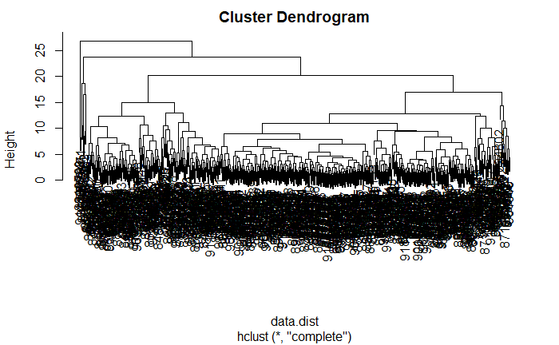

# Gráficos

- Eu meio que posso ver por que poderíamos cortar em 4. Isso nos dá os principais clusers e então temos alguns minúsculos à esquerda.
- Seria legal se pudéssemos colorir as linhas pelo diagnóstico de alguma forma que nos ajudasse a ver onde devemos nos dividir.

# Selecionando o número de clusters

```r
# Modelo
# Corte a árvore para que ela tenha 4 clusters: wisc.hclust.clusters
wisc.hclust.clusters <- cutree(wisc.hclust, k = 4)

# Comparar a associação do cluster com o diagnóstico real
table(wisc.hclust.clusters, diagnosis)
```

```
                    diagnosis
wisc.hclust.clusters   0   1
                   1  12 165
                   2   2   5
                   3 343  40
                   4   0   2
```

```r
# Contagem de observações fora do lugar com base no cluster
# Basicamente apenas somando os minutos da linha aqui

sum(apply(table(wisc.hclust.clusters, diagnosis), 1, min))
```

```
[1] 54
```

- Parece que 54 tumores não estão claros com o diagnóstico baseado no cluster geral

# Modelo KMEANS

- k-means agrupando e comparando resultados

```r
# Crie um modelo k-means em wisc.data: wisc.km
head(wisc.data)
```

```
         radius_mean texture_mean perimeter_mean area_mean smoothness_mean compactness_mean concavity_mean concave.points_mean symmetry_mean fractal_dimension_mean radius_se texture_se perimeter_se
842302         17.99        10.38         122.80    1001.0         0.11840          0.27760         0.3001             0.14710        0.2419                0.07871    1.0950     0.9053        8.589
842517         20.57        17.77         132.90    1326.0         0.08474          0.07864         0.0869             0.07017        0.1812                0.05667    0.5435     0.7339        3.398
84300903       19.69        21.25         130.00    1203.0         0.10960          0.15990         0.1974             0.12790        0.2069                0.05999    0.7456     0.7869        4.585
84348301       11.42        20.38          77.58     386.1         0.14250          0.28390         0.2414             0.10520        0.2597                0.09744    0.4956     1.1560        3.445
84358402       20.29        14.34         135.10    1297.0         0.10030          0.13280         0.1980             0.10430        0.1809                0.05883    0.7572     0.7813        5.438
843786         12.45        15.70          82.57     477.1         0.12780          0.17000         0.1578             0.08089        0.2087                0.07613    0.3345     0.8902        2.217
         area_se smoothness_se compactness_se concavity_se concave.points_se symmetry_se fractal_dimension_se radius_worst texture_worst perimeter_worst area_worst smoothness_worst compactness_worst
842302    153.40      0.006399        0.04904      0.05373           0.01587     0.03003             0.006193        25.38         17.33          184.60     2019.0           0.1622            0.6656
842517     74.08      0.005225        0.01308      0.01860           0.01340     0.01389             0.003532        24.99         23.41          158.80     1956.0           0.1238            0.1866
84300903   94.03      0.006150        0.04006      0.03832           0.02058     0.02250             0.004571        23.57         25.53          152.50     1709.0           0.1444            0.4245
84348301   27.23      0.009110        0.07458      0.05661           0.01867     0.05963             0.009208        14.91         26.50           98.87      567.7           0.2098            0.8663
84358402   94.44      0.011490        0.02461      0.05688           0.01885     0.01756             0.005115        22.54         16.67          152.20     1575.0           0.1374            0.2050
843786     27.19      0.007510        0.03345      0.03672           0.01137     0.02165             0.005082        15.47         23.75          103.40      741.6           0.1791            0.5249
         concavity_worst concave.points_worst symmetry_worst fractal_dimension_worst
842302            0.7119               0.2654         0.4601                 0.11890
842517            0.2416               0.1860         0.2750                 0.08902
84300903          0.4504               0.2430         0.3613                 0.08758
84348301          0.6869               0.2575         0.6638                 0.17300
84358402          0.4000               0.1625         0.2364                 0.07678
843786            0.5355               0.1741         0.3985                 0.12440
```

# Modelo

```r
# Modelo
wisc.km <- kmeans(scale(wisc.data), centers = 2, nstart = 20)

# Comparar k-means com diagnósticos reais
table(wisc.km$cluster, diagnosis)
```

```
   diagnosis
      0   1
  1 343  37
  2  14 175
```

# Resultado modelo

- 51 tumores com o diagnóstico baseado no cluster geral

```r
sum(apply(table(wisc.km$cluster, diagnosis), 1, min))
```

```
[1] 51
```

# Comparar k-means com agrupamento hierárquico

```r
# Tabela
table(wisc.hclust.clusters, wisc.km$cluster)
```

```
wisc.hclust.clusters   1   2
                   1  17 160
                   2   0   7
                   3 363  20
                   4   0   2
```

# Agrupamento nos resultados do PCA

- Lembre-se de exercícios anteriores que o modelo PCA exigia significativamente menos recursos para descrever 80% e 95% da variabilidade dos dados.
- Além de normalizar os dados e potencialmente evitar overfitting, o PCA também descorrelaciona as variáveis, algumas vezes melhorando o desempenho de outras técnicas de modelagem.

```r
# Crie um modelo de cluster hierárquico: wisc.pr.hclust
summary(wisc.pr)
```

```
Importance of components:
                          PC1    PC2     PC3     PC4     PC5     PC6     PC7     PC8    PC9    PC10   PC11    PC12    PC13    PC14    PC15    PC16    PC17    PC18    PC19    PC20   PC21    PC22    PC23
Standard deviation     3.6444 2.3857 1.67867 1.40735 1.28403 1.09880 0.82172 0.69037 0.6457 0.59219 0.5421 0.51104 0.49128 0.39624 0.30681 0.28260 0.24372 0.22939 0.22244 0.17652 0.1731 0.16565 0.15602
Proportion of Variance 0.4427 0.1897 0.09393 0.06602 0.05496 0.04025 0.02251 0.01589 0.0139 0.01169 0.0098 0.00871 0.00805 0.00523 0.00314 0.00266 0.00198 0.00175 0.00165 0.00104 0.0010 0.00091 0.00081
Cumulative Proportion  0.4427 0.6324 0.72636 0.79239 0.84734 0.88759 0.91010 0.92598 0.9399 0.95157 0.9614 0.97007 0.97812 0.98335 0.98649 0.98915 0.99113 0.99288 0.99453 0.99557 0.9966 0.99749 0.99830
                         PC24    PC25    PC26    PC27    PC28    PC29    PC30
Standard deviation     0.1344 0.12442 0.09043 0.08307 0.03987 0.02736 0.01153
Proportion of Variance 0.0006 0.00052 0.00027 0.00023 0.00005 0.00002 0.00000
Cumulative Proportion  0.9989 0.99942 0.99969 0.99992 0.99997 1.00000 1.00000
```

```r
wisc.pr.hclust <- hclust(dist(wisc.pr$x[, 1:7]), method = "complete")

# Corte o modelo em 4 clusters: wisc.pr.hclust.clusters
wisc.pr.hclust.clusters <- cutree(wisc.pr.hclust, k = 4)

# Compare com diagnósticos reais
t <- table(wisc.pr.hclust.clusters, diagnosis)
t
```

```
                       diagnosis
wisc.pr.hclust.clusters   0   1
                      1   5 113
                      2 350  97
                      3   2   0
                      4   0   2
```

```r
# Resultado final
sum(apply(t, 1, min))
```

```
[1] 102
```

- Resultado deu positivo com 102 caos de casos tipo de tumores

```r
t
```

[output not shown]

```r
# Resultado do KMEANS
sum(apply(t, 1, min))
```

[output not shown]

```r
t <- table(wisc.km$cluster, diagnosis)
t
```

```
   diagnosis
      0   1
  1 343  37
  2  14 175
```

```r
sum(apply(t, 1, min))
```

```
[1] 51
```

- Parece que o 2 cluster k-means faz o melhor trabalho
- Todo o propósito disso é ver se os resultados do agrupamento podem ser úteis em um processo de aprendizado supervisionado.
  - Acho que pode valer a pena adicionar os clusters k-means a um modelo. Pode ser. Eu acho que eu poderia tentar com e sem e ver o que é melhor em prever agora que eu sei como fazer isso. : )

# Conclusão

- Esta foi uma visão geral de alto nível sobre os tópicos de clustering hierárquico e k-means e PCA
- Acho que abrange alguns bons conceitos, como seleção de modelos de variáveis, interpretação e dimensionamento de dados
- Eu tive um pouco de intuição sobre como os algoritmos funcionam
- Não sinto que conheço bem esses tópicos ou que estou pronto para basear as decisões de negócios no meu conhecimento dessas técnicas de modelo.
- Foi uma boa maneira de começar e agora estou definitivamente pronto para aprofundar essas técnicas.

# Observação

Neste modelo ML curso da datacamp de machine learning - Aprendizado não supervisionado em R